# Series de tiempo

Luis Apáez

26/2/2022

## Estimación de la tendencia y la componente estacional: método S1

Recordemos que en este caso estimamos la tendencia calculando el promedio por año:

$$\hat{\mu_{j}}=\frac{1}{12}\sum_{k=1}^{12}x_{j,k}, \ \ \ \ \ j=1,\ldots,r$$

es decir, fijamos un año y el promedio corre sobre el ciclo estacional $k$. De forma similar estimamos la componente estacional como

$$\hat{s_{k}}=\frac{1}{r}\sum_{j=1}^{12}(x_{j,k}-\hat{\mu_{j}}), \ \ \ \ \ k=1,\ldots,r$$

es decir, fijamos el ciclo estacional $k$ y corremos el promedio sobre los años, donde en este promedio quitamos la parte de la tendencia para cada respectivo año. Finalmente, para la parte aleatoria quitaremos la parte d ela tendencia y de la componente estacional.

### Ejemplo

Utilizaremos los datos de `USAccDeaths` (muertes accidentales en EU)

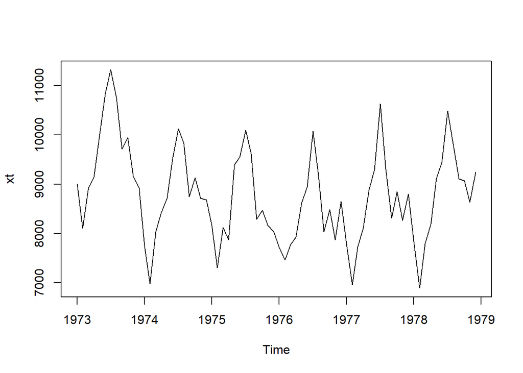

```r
# Cargamos la librería necesaria
library(forecast)

# guardamos los datos
xt = USAccDeaths

# vemos la gráfica de la ST
plot(xt)
```

notamos que el ciclo se repite cada año y los datos abarcan 6 años ($j=1,\ldots,6$). Así, utilizando el método $S1$ estimamos la componente de la tendencia ($\hat{\mu_{j}}$) como sigue:

- Tomando $j=1$ realizaremos la suma de los datos de la ST sobre los meses y dividimos dicha suma entre 12

```r
sum( xt[1:12] ) / 12
```

[output not shown]

- Para $j=2$ haremos lo mismo, pero ahora nos interesan los datos del segundo año, o lo que es lo mismo, nos interesan los datos de la segunda fila:

```r
sum( xt[12 + 1:12] ) / 12
```

[output not shown]

donde recordemos que la primer fila de la ST es de la forma $x_{1}, x_{2},\ldots,x_{12}$ y la segunda fila $x_{13}, x_{14},\ldots,x_{24}$, de ahí que hayamos colocado `xt[12 + 1:12]` para acceder a estos datos de la ST. De forma general

```r
# creamos un vector vacío para que almacene los valores
mj = c()

# usamos un for para recorrer todos los años de los datos de la ST
for(j in 1:6){
  mj[j] = sum( xt[12*(j-1)+1:12] ) / 12
}
mj
```

```
## [1] 9651.750 8718.500 8588.583 8395.083 8576.833 8802.000
```

Hacemos lo mismo para estimar la componente estacional

```r
# vector vacío
sk = c()

# usamos un for para recorrer todos los meses
for(k in 1:12){
  sk[k] = sum( xt[(0:5)*12+k]-mj ) / 6
}
```

donde `xt[(0:5)*12+k]-mj` nos permite acceder a los datos de la ST con índice $1,13,25,37,49,61$ para $k=1$ (Enero), etcétera.

Finalmente estimamos la parte aleatoria

```r
aleatorio = xt - rep(mj, each = 12) - rep(sk, times = 6)
```

donde, como los datos de la ST son de 6 años con periodo de 12 meses, entonces podemos pensar a los datos como una tabla de 6 filas por 12 columnas. De tal manera, a la ST `xt` le restaremos entrada por entrada los valores obtenido es `mj` y `sk`.

Podemos ver graficamente la parte aleatoria obtenida y la gráfica de la ST

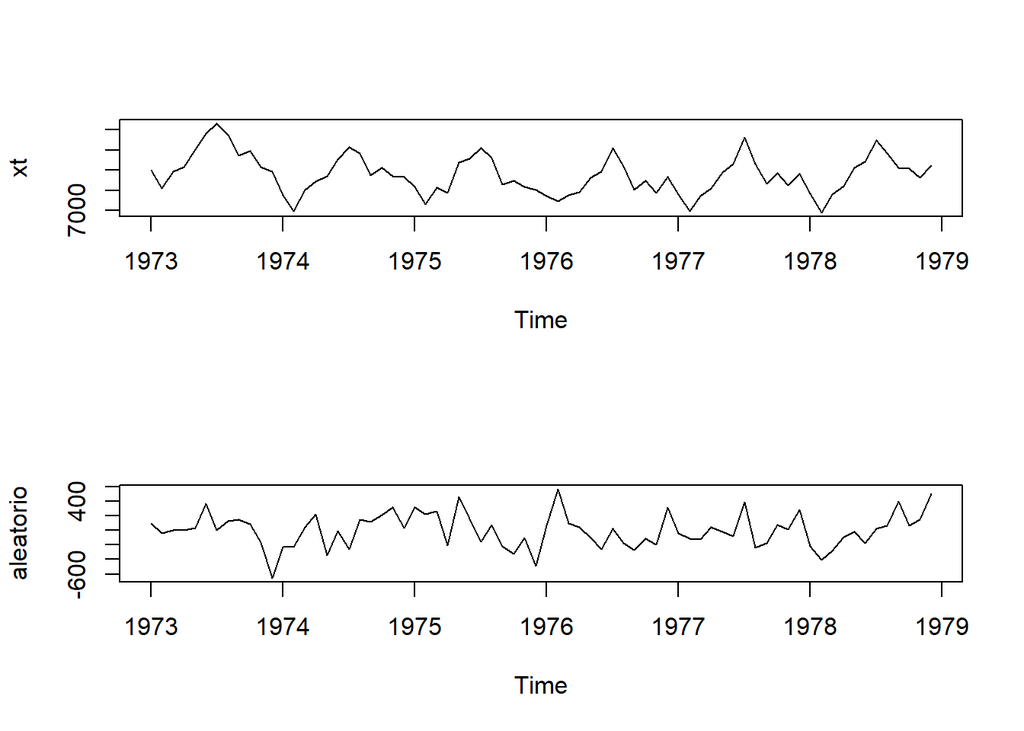

```r
par(mfrow=c(2,1))
plot(xt)
plot(aleatorio)
```

asimismo, podemos graficar, en azul, la estimación de la componente de la tendencia junto con la estimación de la componente estacional

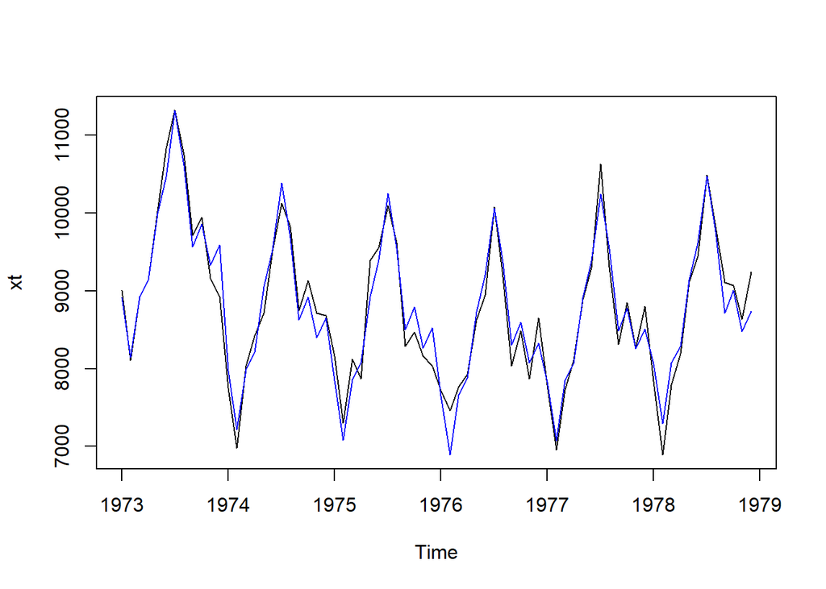

```r
# compenente estacional y de tendencia (estimación)
compon = rep(mj, each = 12) + rep(sk, times = 6)

# lo adecuamos a los datos de la ST
compon = ts(compon, start=start(xt), frequency=12)

# graficamos
plot(xt)
lines(compon,col="blue")
```

## Estimación de la tendencia y la componente estacional: método S2

Recordemos que para este caso debemos identificar primero el periodo de la parte estacional, de modo que en este caso $d=12$; además, dado que la ST abarca 6 años, tenemos que $k=6$. De tal manera, $n=k\cdot d=6\cdot 12=72$. En efecto

```r
length(xt)
```

```
## [1] 72
```

Ahora, dado que $d$ es par, tenemos entonces $12 =2q $, de donde $q=6$. Luego

```r
d = 12
k = 6
n = 72
q = 6
```

tenemos entonces que el estimador de la tendencia está dado por:

```r
# Definimos una ST sólo con entradas "NA" de acuerdo al número de
# entradas de la ST original
mt = ts(rep(NA, n), start = start(xt), frequency = frequency(xt))

# Realizamos la suma
for(t in (q+1):(n-q)){
  mt[t] = (0.5 * xt[t - q] + sum( xt[(t-q+1):(t+q-1)] ) + 0.5 * xt[t + q]) / d
}
```

donde recordemos que $q+1\leq t\leq n-q$ y además la fórmula para estimar la tendencia es

$$\hat{m_{t}}=\frac{0.5 x_{t-q}+x_{t-q+1}+\cdots+x_{t+q-1}+0.5x_{t+q}}{d}$$

dado que en las primeras $q$ entradas de la ST no estamos obteniendo esta estimación de la tendnecia, y dado que tampoco estamos realizando esta estimación para los últimos datos (i.e $t>n-q$), hacemos que en ambos casos la tendencia sea constante

```r
mt[1:q] = mt[q+1]
mt[(n-q+1):n] = mt[n-q]
```

Lo que sigue es quitar la tendencia a la serie original ($z_{t}=x_{t}-\hat{\mu_{t}}$)

```r
zt = xt - mt
```

Después, a la ST auxiliar $z_{t}$ crearemos un ciclo promedio ($w_{k}$, $k=1,\ldots, 12$) que estimará la parte estacional:

```r
wk  = rep(NA, 12)

for(k in 1:12){
  wk[k] = sum(zt[(0:5)*12 + k], na.rm = TRUE) / 6
}
```

donde para $k=1$ tendríamos que promediar los datos $z_{1}, z_{13}, z_{25}, z_{37}, z_{49}, z_{61}$, etcétera.

Continuamos ajustando el ciclo obtenido en la serie como

$$\hat{S_{k}}=w_{k}-\frac{\sum_{i=1}^{d}w_{i}}{d}, \ \ \ k\in\{1,\ldots,12\}$$

```r
# Vec_ciclo:

sk  = rep(NA, 12)

for(k in 1:12){
  sk[k] = wk[k] - sum(wk) / d
}
```

Finalmente repetimos el vector $Vec_{ciclo}$ tantos ciclos tengamos (a lo cual denominaremos $S_{t}$), en este caso repetiremos el vector `sk` 6 veces:

```r
# Adaptamos los datos a una serie de tiempo
St = ts(rep(sk, times=6), start=start(xt), frequency=frequency(xt))
```

Podemos calcular la parte aleatoria como $y_{t}=z_{t}-S_{t}$

```r
aleatorio = zt-St
```

Finalmente vemos los resultados:

1. La ST original junto con la estimación de la tendencia y la estimación del ciclo

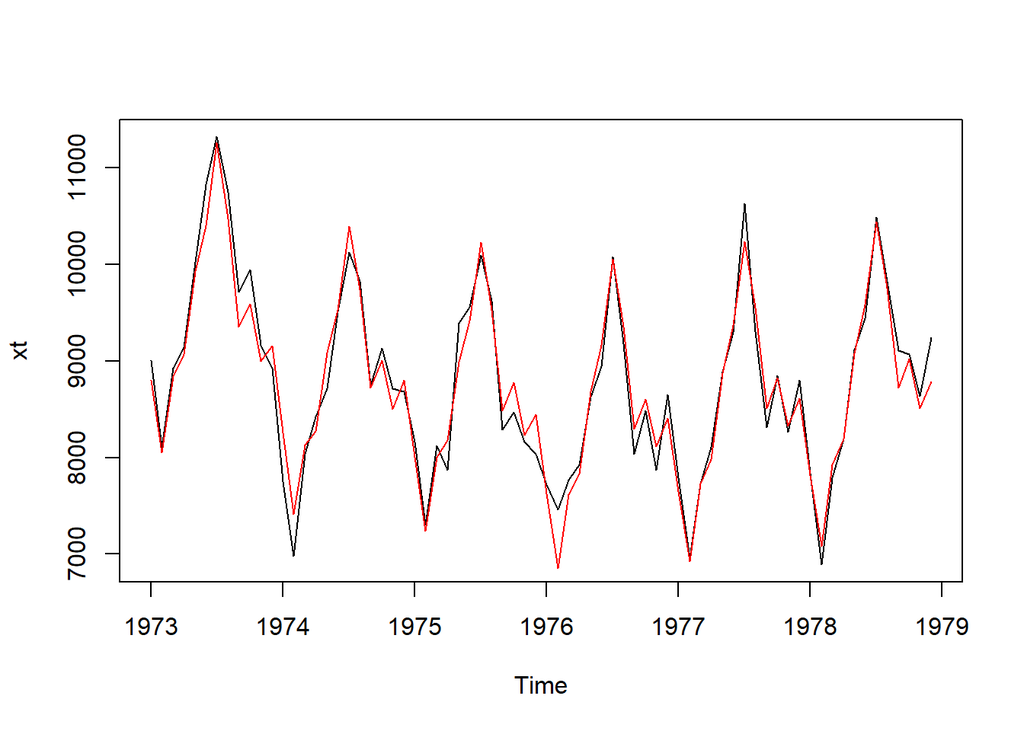

```r
# Componente de la tendencia más componente estacional
compon = mt + St

# Lo adaptamos a una ST
compon = ts(compon, start=start(xt), frequency = 12)

# Graficamos
plot(xt)
lines(compon,col="red")
```

y finalmente podemos observar la tendencia estimada, el ciclo estimado y la parte aleatoria (respectivamente):

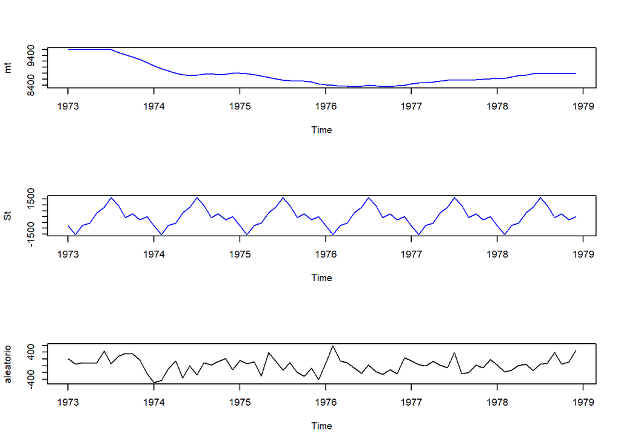

```r
par(mfrow=c(3,1))
plot(mt, col="blue")
plot(St, col="blue")
plot(aleatorio)
```